# Public Health and Economic Consequences of Severe Weather Events

## SYNOPSIS

This study examines the NOAA storm event database to determine which types of weather events are the most harmful to human populations and economically. After normalizing the data, analyses were based on the data collected between 1996 and 2011, comprised of 48 categories of events. ‘Population Cost’ was determined by looking separately at fatality and injury counts per event, ‘Economic Cost’ was determined as a combination of property and crop damage totals.

The events with the highest population cost were Excessive Heat events (highest fatalities) and Tornadoes (highest injuries, highest combinied population impact). Floods/flash floods were also of note from a population cost standpoint.

The events with the highest economic cost were all water-related, with flooding being the most costly. Also notable in terms of economic damage are hurricanes/typhoons and storm tides.

## DATA PROCESSING

Libraries required include `tm`, `stringdist`, `stringr`, `ggplot2`, `gridExtra`, and `scales`. Local system must also have a pdf processor installed. I used `xpdf` on mac.

```r
library(tm)         # PDF processing
```

```r
library(stringdist) # Approximate string matching
library(stringr)    # Consistent regex
library(ggplot2)    # Plots
library(gridExtra)  # Layout of plots
library(scales)     # Non-Scientific Notation Plot Scales
```

### SOURCING DATA

First we download and extract the NOAA storm data.

```r
# Check for data dir
if (!file.exists("data")) {
  dir.create("data")
}

# Check for data source file, download if needed.
if (!file.exists("data/noaa_storm_data.bz2")) {
  download.file("https://d396qusza40orc.cloudfront.net/repdata%2Fdata%2FStormData.csv.bz2", destfile="data/noaa_storm_data.bz2", method="curl")
}

noaa <- read.csv('data/noaa_storm_data.bz2',
                 header = TRUE, stringsAsFactors = FALSE, strip.white=TRUE)
dim(noaa)
```

```
## [1] 902297     37
```

Also let’s grab the documentation from http://www.ncdc.noaa.gov/stormevents/pd01016005curr.pdf. Linux/Mac package ‘xpdf’ is required to extract the 48 categories. (credit to https://class.coursera.org/repdata-035/forum/thread?thread_id=35 for the idea).

```r
if (!file.exists("data/pd01016005curr.pdf")) {
  download.file("http://www.ncdc.noaa.gov/stormevents/pd01016005curr.pdf", destfile="data/pd01016005curr.pdf", method="curl")
}

# Read the PDF using `tm`'s `readPDF`.  This requires a pdf engine, I used
# xpdf on a mac.
pdf <- readPDF(control = list(c(text = "-layout")))
pdf <- pdf(elem=list(uri="data/pd01016005curr.pdf"),language="en")
```

### PROCESSING CATEGORY DATA

We extract the 48 ‘official’ categories from the table of contents in the source document. These are matched by their format: 7.(1 or two digit number), space, text, space, event designator in parens. Then we strip the leading/trailing metainformation.

```r
# Extract the 'Event Types' from the table of contents
toc <- paste(pdf$content[78:91], collapse = ' ')

# Then extract the 48 'official' category names.
# We match them based on their format: 7.(1 or two digit number),
# space, text, space, event designator in parens.
categories <- str_extract_all(toc, "7\\.[:digit:]+\\.? ([^\\)]*) \\([CMZ]\\)")[[1]]

# Then we strip the leading/trailing metainformation
categories <- str_replace(categories, "^7\\.[:digit:]+\\.? ", "")
categories <- str_replace(categories, "[:space:]+\\([CMZ]\\)$", "")

print(categories)
```

```
##  [1] "Astronomical Low Tide"    "Avalanche"
##  [3] "Blizzard"                 "Coastal Flood"
##  [5] "Cold/Wind Chill"          "Debris Flow"
##  [7] "Dense Fog"                "Dense Smoke"
##  [9] "Drought"                  "Dust Devil"
## [11] "Dust Storm"               "Excessive Heat"
## [13] "Extreme Cold/Wind Chill"  "Flash Flood"
## [15] "Flood"                    "Freezing Fog"
## [17] "Frost/Freeze"             "Funnel Cloud"
## [19] "Hail"                     "Heat"
## [21] "Heavy Rain"               "Heavy Snow"
## [23] "High Surf"                "High Wind"
## [25] "Hurricane/Typhoon"        "Ice Storm"
## [27] "Lakeshore Flood"          "Lake-Effect Snow"
## [29] "Lightning"                "Marine Hail"
## [31] "Marine High Wind"         "Marine Strong Wind"
## [33] "Marine Thunderstorm Wind" "Rip Current"
## [35] "Seiche"                   "Sleet"
## [37] "Storm Tide"               "Strong Wind"
## [39] "Thunderstorm Wind"        "Tornado"
## [41] "Tropical Depression"      "Tropical Storm"
## [43] "Tsunami"                  "Volcanic Ash"
## [45] "Waterspout"               "Wildfire"
## [47] "Winter Storm"             "Winter Weather"
```

### PROCESSING STORM EVENT DATA

We’ll first separate the data into groups by the collection year. We need to coerce a date. For our purposes, we’ll determine the event’s year by the beginning date of the event.

Then we’ll assign a ‘collection category’ corresponding to the information from here: http://www.ncdc.noaa.gov/stormevents/details.jsp. The categories are

- `tornado`: Tornado only
- `ttws1`: Tornado, Thunderstorm Wind and Hail 1 (manually keyed)
- `ttws2`: Tornado, Thunderstorm Wind and Hail 2 (text files)
- `all`: All event types

```r
noaa$event_date <- as.Date(strptime(noaa$BGN_DATE, "%m/%d/%Y %H:%M:%S"))
noaa$event_year <- strftime(noaa$event_date, "%Y")
noaa$collection_category <- apply(noaa, 1, function(row){
  y <- as.numeric(row['event_year'])
  if (y < 1955) { 'tornado_only' }
  else if (y >= 1955 & y < 1993) { 'ttws1' }
  else if (y >= 1992 & y < 1996) { 'ttws2' }
  else if (y >= 1996) { 'all' }
})

table(noaa$collection_category)
```

```
##
##          all tornado_only        ttws1        ttws2
##       653530         1865       185694        61208
```

Now let’s work on shrinking our working dataset a little bit.

We start by removing the columns we don’t care about from the dataset.

```r
dim(noaa)
```

```
## [1] 902297     40
```

```r
object.size(noaa)
```

```
## 511052328 bytes
```

```r
noaa <- subset(noaa, select = c('event_year',
                                'collection_category',
                                'PROPDMG', 'PROPDMGEXP',
                                'CROPDMG', 'CROPDMGEXP',
                                'FATALITIES', 'INJURIES',
                                'EVTYPE'))
dim(noaa)
```

```
## [1] 902297      9
```

```r
object.size(noaa)
```

```
## 65033992 bytes
```

We’re going to disregard the tornado-only data, since it’s not likely to be very useful in a comparison (there being nothing in those years’ data to compare to). We’ll retain the post-1955 data.

```r
noaa <- noaa[noaa$collection_category != 'tornado_only', ]
dim(noaa)
```

```
## [1] 900432      9
```

```r
object.size(noaa)
```

```
## 68501136 bytes
```

We also don’t care about entries with no ‘population’ or ‘economic’ cost, so in this case, if the record doesn’t have values for any of ‘PROPDMG’, ‘CROPDMG’, ‘FATALITIES’, ‘INJURIES’, we’ll let it go.

We’ll store this one off to a separate variable, because relative frequency of impactful events may be interesting (even if not all of those events cause damage). We don’t need or want to normalize the categories for occurrences that are ONLY for nonzero economic/personal cost observations.

```r
noaa_lim <- noaa[rowSums(noaa[ , c('PROPDMG', 'CROPDMG', 'FATALITIES', 'INJURIES')]) > 0, ]
dim(noaa_lim)
```

```
## [1] 253046      9
```

```r
object.size(noaa_lim)
```

```
## 19267496 bytes
```

There are WAY TOO MANY event types listed for the remaining data.

```r
length(unique(noaa_lim$EVTYPE))
```

```
## [1] 488
```

We try to match some of them up to the 48 categories.

```r
# exact match, not very good.
table(noaa_lim$EVTYPE %in% categories)
```

```
##
##  FALSE   TRUE
## 253027     19
```

```r
# case normalized string match.  better, but still not very good.
table(tolower(noaa_lim$EVTYPE) %in% tolower(categories))
```

```
##
##  FALSE   TRUE
##  81736 171310
```

H/T https://class.coursera.org/repdata-035/forum/thread?thread_id=8#post-284 for the idea to use amatch to correct for typographical errors. Assuming a max typo/whitespace difference of 3 characters, we see the following

```r
table(amatch(tolower(noaa_lim$EVTYPE), tolower(categories), maxDist = 3, nomatch = -1))
```

```
##
##    -1     1     2     3     4     5     7     8     9    10    11    12
## 67898     2   269   253   229    90    74     1   266    95   103   698
##    13    14    15    16    17    18    19    20    21    22    23    24
##   111 21285 10388     7   118    13 26138   215  1134  1377   146  6182
##    25    26    27    28    29    30    31    32    33    34    35    36
##    72   709     5   198 13296     2    19    46    33   641    33     1
##    38    39    40    41    42    43    44    45    46    47    48
##  3424 55801 38373    35   416    14     2    54   864  1509   407
```

We partially populate the table, so we’re working with fewer records going forward.

```r
noaa_lim$category <- categories[amatch(tolower(noaa_lim$EVTYPE), tolower(categories), maxDist = 3)]
```

There are still a bunch of unmatched entries

```r
head(sort(table(noaa_lim[is.na(noaa_lim$category), ]$EVTYPE), decreasing=TRUE), 20)
```

```
##
##            TSTM WIND URBAN/SML STREAM FLD       TSTM WIND/HAIL
##                63234                  702                  441
##     WILD/FOREST FIRE    FLOOD/FLASH FLOOD         EXTREME COLD
##                  388                  279                  197
##            LANDSLIDE          STORM SURGE          URBAN FLOOD
##                  193                  177                  139
##   WINTER WEATHER/MIX            HURRICANE           LIGHT SNOW
##                  139                  129                  119
##     MARINE TSTM WIND          RIVER FLOOD                 WIND
##                  109                  107                   83
##       URBAN FLOODING       DRY MICROBURST                 SNOW
##                   80                   78                   52
## HEAVY SURF/HIGH SURF     STORM SURGE/TIDE
##                   50                   47
```

but we can clean some/most of these up. thunderstorm/tstm wind is the VAST majority of these, and some of the others are relatively easy to match. We’ll match all the ones that occur with some frequency, and some of the ones that are easy to determine. We avoid matching things that combine categories, or are nondeterminant (like SNOW, it could possibly fit in several of the specified categories)

The process used to match these is as follows:

- Any `EVTYPE` with ‘thunderstorm’ or ‘tstm’, and without ‘marine’ = `Thunderstorm Wind`
- Any `EVTYPE` with both ‘flash’ and ‘flood’ = `Flash Flood`
- Any remaining `EVTYPE`s with ‘flood’ = `Flood`
- Any `EVTYPE` with both ‘wild’ and ‘fire’ = `Wildfire`
- Any `EVTYPE` with both ‘ext’ and ‘cold’ = `Extreme Cold/Wind Chill`
- Any `EVTYPE` with ‘landslide’ = `Debris Flow`
- Any `EVTYPE` with ‘storm surge’ = `Storm Tide`
- Any `EVTYPE` with either ‘hurricane’ or ‘typhoon’ = `Hurricane/Typhoon`
- Any `EVTYPE` with ‘hail’ = `Hail`
- Any `EVTYPE` with either ‘winter’ or ‘light snow’ = `Winter Weather`

```r
# update thunderstorm wind to include anything non-marine with thunderstorm/tstm
# (other tstorm related issues would be coded as lightning or tornado damage)
noaa_lim$category <- ifelse( is.na(noaa_lim$category) &
                         grepl("(tstm|thunderstorm)", tolower(noaa_lim$EVTYPE)) &
                         !grepl("marine", tolower(noaa_lim$EVTYPE)),
                         "Thunderstorm Wind", noaa_lim$category)

# Manually take on marine t-storm wind.
noaa_lim$category <- ifelse(is.na(noaa_lim$category) & grepl("marine tstm wind", tolower(noaa_lim$EVTYPE)), "Marine Thunderstorm Wind", noaa_lim$category)

# if it matches both 'flash' and 'flood', it's a flash flood
noaa_lim$category <- ifelse(is.na(noaa_lim$category) & grepl("flash", tolower(noaa_lim$EVTYPE)) & grepl("flood", tolower(noaa_lim$EVTYPE)), "Flash Flood", noaa_lim$category)

# if it matches 'flood' (or stream fld), it's a 'regular' flood
noaa_lim$category <- ifelse(is.na(noaa_lim$category) & grepl("(flood|stream fld)", tolower(noaa_lim$EVTYPE)), "Flood", noaa_lim$category)

# wildfire
noaa_lim$category <- ifelse(is.na(noaa_lim$category) & grepl("wild", tolower(noaa_lim$EVTYPE)) & grepl("fire", tolower(noaa_lim$EVTYPE)), "Wildfire", noaa_lim$category)

# extreme cold
noaa_lim$category <- ifelse(is.na(noaa_lim$category) & grepl("ext", tolower(noaa_lim$EVTYPE)) & grepl("cold", tolower(noaa_lim$EVTYPE)), "Extreme Cold/Wind Chill", noaa_lim$category)

# Hurricanes / Tsunamis
noaa_lim$category <- ifelse(is.na(noaa_lim$category) & grepl("(hurricane|typhoon)", tolower(noaa_lim$EVTYPE)), "Hurricane/Typhoon", noaa_lim$category)

# landslides = debris flow
noaa_lim$category <- ifelse(is.na(noaa_lim$category) & grepl("landslide", tolower(noaa_lim$EVTYPE)), "Debris Flow", noaa_lim$category)

# storm surge = storm tide
noaa_lim$category <- ifelse(is.na(noaa_lim$category) & grepl("storm surge", tolower(noaa_lim$EVTYPE)), "Storm Tide", noaa_lim$category)

# hail
noaa_lim$category <- ifelse(is.na(noaa_lim$category) & grepl("hail", tolower(noaa_lim$EVTYPE)), "Hail", noaa_lim$category)

# probably safe to say 'winter' is winter weather.  We'll allow 'light snow' here too.
noaa_lim$category <- ifelse(is.na(noaa_lim$category) & grepl("(winter|light snow)", tolower(noaa_lim$EVTYPE)), "Winter Weather", noaa_lim$category)
```

This takes care of all the uncategorized event types with more than 100 observations (and nonzero economic/population cost)

```r
head(sort(table(noaa_lim[is.na(noaa_lim$category), ]$EVTYPE), decreasing=TRUE), 20)
```

```
##
##                 WIND       DRY MICROBURST                 SNOW
##                   83                   78                   52
## HEAVY SURF/HIGH SURF        FREEZING RAIN            HEAT WAVE
##                   50                   35                   34
##                OTHER       EXCESSIVE SNOW            ICY ROADS
##                   33                   25                   22
##  LIGHT FREEZING RAIN          GUSTY WINDS   HEAVY SNOW SQUALLS
##                   22                   21                   21
##    EXTREME WINDCHILL                GLAZE                WINDS
##                   19                   19                   18
##         EXTREME HEAT               FREEZE          SNOW SQUALL
##                   17                   16                   16
##   HEAVY SNOW-SQUALLS  MIXED PRECIPITATION
##                   15                   15
```

And leaves less than 0.4% of the observations we’re interested in outside of one of the 48 major categories.

```r
table(is.na(noaa_lim$category))['TRUE'] / nrow(noaa_lim) * 100
```

```
##      TRUE
## 0.3924188
```

Let’s apply the process to the non-limited dataset, so we’ll have accurate totals for occurrences of each of the types when we look at freqeuencies.

```r
noaa$category <- categories[amatch(tolower(noaa$EVTYPE), tolower(categories), maxDist = 3)]
noaa$category <- ifelse( is.na(noaa$category) &
                         grepl("(tstm|thunderstorm)", tolower(noaa$EVTYPE)) &
                         !grepl("marine", tolower(noaa$EVTYPE)),
                         "Thunderstorm Wind", noaa$category)
noaa$category <- ifelse(is.na(noaa$category) & grepl("marine tstm wind", tolower(noaa$EVTYPE)), "Marine Thunderstorm Wind", noaa$category)
noaa$category <- ifelse(is.na(noaa$category) & grepl("flash", tolower(noaa$EVTYPE)) & grepl("flood", tolower(noaa$EVTYPE)), "Flash Flood", noaa$category)
noaa$category <- ifelse(is.na(noaa$category) & grepl("(flood|stream fld)", tolower(noaa$EVTYPE)), "Flood", noaa$category)
noaa$category <- ifelse(is.na(noaa$category) & grepl("wild", tolower(noaa$EVTYPE)) & grepl("fire", tolower(noaa$EVTYPE)), "Wildfire", noaa$category)
noaa$category <- ifelse(is.na(noaa$category) & grepl("ext", tolower(noaa$EVTYPE)) & grepl("cold", tolower(noaa$EVTYPE)), "Extreme Cold/Wind Chill", noaa$category)
noaa$category <- ifelse(is.na(noaa$category) & grepl("(hurricane|typhoon)", tolower(noaa$EVTYPE)), "Hurricane/Typhoon", noaa$category)
noaa$category <- ifelse(is.na(noaa$category) & grepl("landslide", tolower(noaa$EVTYPE)), "Debris Flow", noaa$category)
noaa$category <- ifelse(is.na(noaa$category) & grepl("storm surge", tolower(noaa$EVTYPE)), "Storm Tide", noaa$category)
noaa$category <- ifelse(is.na(noaa$category) & grepl("hail", tolower(noaa$EVTYPE)), "Hail", noaa$category)
noaa$category <- ifelse(is.na(noaa$category) & grepl("(winter|light snow)", tolower(noaa$EVTYPE)), "Winter Weather", noaa$category)
```

## RESULTS

Since we’re looking to determine the economic and human impacts of storm events, we should begin by determining how we’ll measure each of these and preparing those data.

### Human Impact

For `most harmful with respect to population health`, we’ll take a look at both fatalities and injuries. We’ll aggregate the totals by category over the entire time period, and facet on collection period (to see if the lower number of categories in the `ttws` periods taints the outcome)

```r
# collect the overall totals for facet ordering
af <- aggregate(noaa$FATALITIES,
                     by = list('category' = noaa$category),
                     sum)
af <- af[order(af$x, decreasing = TRUE), ]
af$category <- factor(af$category, levels = af[order(af$x, decreasing = TRUE), ]$category)

# then collect the faceted set for plotting
aggregate_fatalities <- aggregate(noaa$FATALITIES,
                                  by = list('category' = noaa$category,
                                            'collection_category' = noaa$collection_category),
                                  sum)

aggregate_fatalities$collection_category <- factor(aggregate_fatalities$collection_category, levels = c('ttws1', 'ttws2', 'all'))
aggregate_fatalities$category <- factor(aggregate_fatalities$category, levels = af$category)

# Do the same for injuries
ai <- aggregate(noaa$INJURIES,
                     by = list('category' = noaa$category),
                     sum)
ai <- ai[order(ai$x, decreasing = TRUE), ]
ai$category <- factor(ai$category, levels = ai[order(ai$x, decreasing = TRUE), ]$category)

aggregate_injuries   <- aggregate(noaa$INJURIES,
                                  by = list('category' = noaa$category,
                                            'collection_category' = noaa$collection_category),
                                  sum)
aggregate_injuries$collection_category <- factor(aggregate_fatalities$collection_category, levels = c('ttws1', 'ttws2', 'all'))
aggregate_injuries$category <- factor(aggregate_injuries$category, levels = ai$category)
```

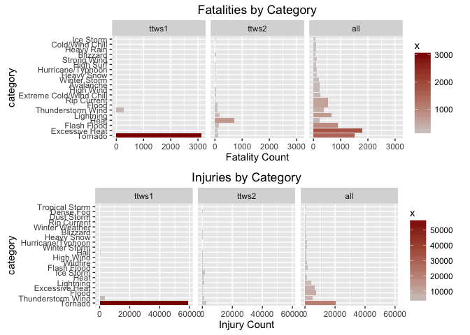

```r
top20_fatalities_faceted <- ggplot(aggregate_fatalities[aggregate_fatalities$category %in% head(af$category, 20), ], aes(x = category, y = x, fill = x)) + geom_bar(stat = 'identity') + scale_fill_gradient2(mid='lightgrey', high='darkred') + coord_flip() + facet_wrap(~ collection_category) + ggtitle('Fatalities by Category') + ylab('Fatality Count')

top20_injuries_faceted <- ggplot(aggregate_injuries[aggregate_injuries$category %in% head(ai$category, 20), ], aes(x = category, y = x, fill = x)) + geom_bar(stat = 'identity') + scale_fill_gradient2(mid='lightgrey', high='darkred') + coord_flip() + facet_wrap(~ collection_category) + ggtitle('Injuries by Category') + ylab('Injury Count')

grid.arrange(top20_fatalities_faceted, top20_injuries_faceted, ncol = 1)
```

From this we can see that the ttws1 period heavily skews our outcomes toward tornadoes (which were likely logged much more frequently than other weather events during the period). What’s more, not much interesting/useful (comparably) comes from ttws2. So for the purposes of this examination, we’ll focus on the ‘all’ period (1996 onwards).

Let’s re-plot just the ‘all observation’ periods:

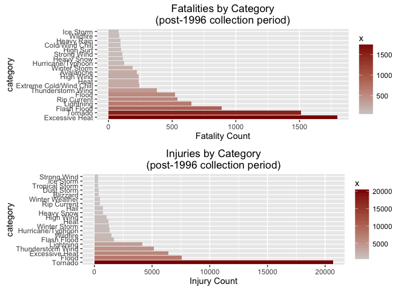

```r
# let's repeat with only the 'all' period
noaa_all <- noaa[noaa$collection_category == 'all', ]

af_all <- aggregate(noaa_all$FATALITIES,
                    by = list('category' = noaa_all$category),
                    sum)
af_all$category <- factor(af_all$category, levels = af_all[order(af_all$x, decreasing = TRUE), ]$category)

ai_all <- aggregate(noaa_all$INJURIES,
                    by = list('category' = noaa_all$category),
                    sum)
ai_all$category <- as.character(ai_all$category)
ai_all$category <- factor(ai_all$category, levels = ai_all[order(ai_all$x, decreasing = TRUE), ]$category)

# And produce plots for just the 'all'
top20_fatalities <- ggplot(head(af_all[order(af_all$x, decreasing = TRUE), ], 20), aes(x = category, y = x, fill = x)) + geom_bar(stat = 'identity') + scale_fill_gradient2(mid='lightgrey', high='darkred') + coord_flip() + ggtitle('Fatalities by Category\n(post-1996 collection period)')  + ylab('Fatality Count')

top20_injuries <- ggplot(head(ai_all[order(ai_all$x, decreasing = TRUE), ], 20), aes(x = category, y = x, fill = x)) + geom_bar(stat = 'identity') + scale_fill_gradient2(mid='lightgrey', high='darkred') + coord_flip() + ggtitle('Injuries by Category\n(post-1996 collection period)') + ylab('Injury Count')

grid.arrange(top20_fatalities, top20_injuries, ncol = 1)
```

We can observe from these plots that the highest fatality count is from Excessive Heat, whereas Tornadoes produce far and away the highest number of injuries. Since tornadoes also produce a very high level of fatalities, any recommendation to focus on particular events for population cost would do well to examine and prepare for Tornadoes and Excessive Heat, and possibly also Flooding/Flash Flooding.

### Economic Impact

For economic impact, we’ll combine property (`PROPDMG`) and crop (`CROPDMG`) damage into a total dollar value per incident.

In the specification document (https://d396qusza40orc.cloudfront.net/repdata%2Fpeer2_doc%2Fpd01016005curr.pdf, section 2.7) it is indicated that the numeric values of damage estimates are rounded to 3 significant digits, then abbreviated by a magnitude indicator

> Alphabetical characters used to signify magnitude include “K” for thousands, “M” for millions, and “B” for billions.

This magnitude indicator is in the `PROPDMGEXP` and `CROPDMGEXP` variables. Some of the magnitude indicators don’t follow the alpha guidelines, and so we don’t know how to normalize them:

```r
# Total nonzero property damage event counts
nonzero_prop_counts <- table(noaa$PROPDMG > 0)
print(nonzero_prop_counts)
```

```
##
##  FALSE   TRUE
## 662794 237638
```

```r
# Table of event counts with nonzero property damage and invalid magnitude indicator
invalid_prop_magnitude_counts <- addmargins(table(noaa[noaa$PROPDMG > 0 & !grepl('[kKmMbB ]', noaa$PROPDMGEXP), ]$PROPDMGEXP))
print(invalid_prop_magnitude_counts)
```

```
##
##       -   +   0   2   3   4   5   6   7   h   H Sum
##  76   1   5 209   1   1   4  18   3   2   1   6 327
```

```r
# Percent of events with nonzero property damage that have an invalid magnitude indicator
(invalid_prop_magnitude_counts['Sum'] / nonzero_prop_counts['TRUE']) * 100
```

```
##       Sum
## 0.1376043
```

```r
# Total nonzero crop damage event counts
nonzero_crop_counts <- table(noaa$CROPDMG > 0)
print(nonzero_crop_counts)
```

```
##
##  FALSE   TRUE
## 878333  22099
```

```r
# Table of event counts with nonzero crop damage and invalid magnitude indicator
invalid_crop_magnitude_counts <- addmargins(table(noaa[noaa$CROPDMG > 0 & !grepl('[kKmMbB ]', noaa$CROPDMGEXP), ]$CROPDMGEXP))
print(invalid_crop_magnitude_counts)
```

```
##
##       0 Sum
##   3  12  15
```

```r
# Percent of events with nonzero crop damage that have an invalid magnitude indicator
(invalid_crop_magnitude_counts['Sum'] / nonzero_crop_counts['TRUE']) * 100
```

```
##        Sum
## 0.06787637
```

Since for both variables these comprise a proportionally very small number of incidents (both less than 0.15 percent), we’ll simply exclude these incidents from our value calculations.

To normalize the values, we’ll decompress and combine the values for property and crop damage, and combine them into a single total dollar value for each incident.

```r
# Populate a column with total economic cost per incident
noaa$economic_cost <- apply(noaa, 1, function(row){
  pval <- as.numeric(row['PROPDMG'])
  if (pval == 0 | !grepl('[kKmMbB ]', row['PROPDMGEXP'])){
    pval <- 0
  } else if (grepl('^[kK]$', row['PROPDMGEXP'])) {
    pval <- pval * 1000
  } else if (grepl('^[mM]$', row['PROPDMGEXP'])) {
    pval <- pval * 1000000
  } else if (grepl('^[bB]$', row['PROPDMGEXP'])) {
    pval <- pval * 1000000000
  }

  cval <- as.numeric(row['CROPDMG'])
  if (cval == 0 | !grepl('[kKmMbB ]', row['CROPDMGEXP'])){
    cval <- 0
  } else if (grepl('^[kK]$', row['CROPDMGEXP'])) {
    cval <- cval * 1000
  } else if (grepl('^[mM]$', row['CROPDMGEXP'])) {
    cval <- cval * 1000000
  } else if (grepl('^[bB]$', row['CROPDMGEXP'])) {
    cval <- cval * 1000000000
  }

  pval + cval
})
```

Now we can aggregate economic cost by event type and compare. Since we’ve already determined there is heavy skew in the pre-1996 data, we’ll be examining only the post-1996 data here. After aggregating, we order the output to be highest aggregate cost to lowest. We also convert the event type to a factor and force-reorder the levels in the same arrangement (for plotting purposes).

```r
noaa_all <- noaa[noaa$collection_category == 'all', ]

aggregate_cost <- aggregate(noaa_all$economic_cost,
                            by = list('category' = noaa_all$category),
                            sum)
aggregate_cost <- aggregate_cost[order(aggregate_cost$x, decreasing = TRUE), ]
head(aggregate_cost, 25)
```

```
##                   category            x
## 15                   Flood 149207700200
## 25       Hurricane/Typhoon  87068996810
## 37              Storm Tide  47835579000
## 40                 Tornado  24900370720
## 19                    Hail  17092605870
## 14             Flash Flood  16557170610
## 9                  Drought  14413667000
## 39       Thunderstorm Wind   8930538480
## 42          Tropical Storm   8320186550
## 46                Wildfire   8162704630
## 24               High Wind   5881921660
## 26               Ice Storm   3657908810
## 47            Winter Storm   1544687250
## 13 Extreme Cold/Wind Chill   1337531400
## 21              Heavy Rain   1313034240
## 17            Frost/Freeze   1104666000
## 29               Lightning    749975520
## 22              Heavy Snow    706929640
## 3                 Blizzard    532718950
## 12          Excessive Heat    500125700
## 4            Coastal Flood    355209560
## 6              Debris Flow    344600000
## 38             Strong Wind    241947740
## 43                 Tsunami    144082000
## 23               High Surf     83929500
```

```r
# Order the categories for the plot
aggregate_cost$category <- factor(aggregate_cost$category, levels = aggregate_cost[order(aggregate_cost$x, decreasing = TRUE), ]$category)
```

Let’s take a look at the event types and see if there’s a clear pattern

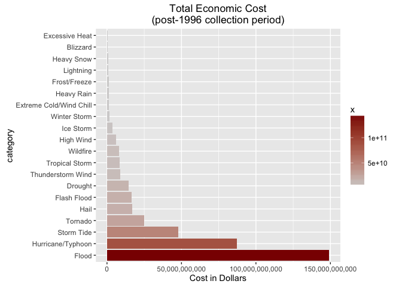

```r
top_25 <- ggplot(head(aggregate_cost[order(aggregate_cost$x, decreasing = TRUE), ], 20), aes(x = category, y = x, fill = x)) + geom_bar(stat = 'identity') + scale_fill_gradient2(mid='lightgrey', high='darkred') + coord_flip() + ggtitle('Total Economic Cost\n(post-1996 collection period)')  + ylab('Cost in Dollars') + scale_y_continuous(labels = comma)

print(top_25)
```

From this analysis, it’s pretty clear that Flooding is the most economically harmful weather event type. Additionally, Hurricanes and Storm Tides (possibly also related to hurricanes or tropical storms) account for a large amount of total economic cost.